# IODS course project

Wilhelm Kvist

# Introduction to Open Data Science - Course Project

# About the project

I’m began my PhD studies at University of Helsinki this Autumn and I’m expecting to be using R as part of my research project in musicology, employing a digital humanities approach. I’ve previously been taking courses on statistics (including analysis in R) via the open universities at University of Helsinki and the Hanken School of Economics. I recently got a new computer (and unfortunately lost most of my scripts from earlier courses), so I’m taking a fresh start on using R again now.

Hitherto, I’ve most often processed my numbers using spreadsheets such as Excel and Google Sheets, and I’ve developed techniques to do my calculations quickly in these programs. The downside to this is that I’ve most often felt that the threshold has been lower to use a spreadsheet than using R when processing numbers (and the quickest calculator is still the Spotlight in Mac Os X). So during this course, I hope to be able to learn some useful techniques for making sense of data quickly. Perhaps R Studio might become my program of choice some day. :)

The address to my Github repository is http://github.com/wilhelmkvist/IODS-project.

```r
# This is a so-called "R chunk" where you can write R code.

date()
```

```
## [1] "Thu Nov 18 14:47:23 2021"
```

# RStudio Exercise 2

*Describe the work you have done this week and summarize your learning.*

- Describe your work and results clearly.
- Assume the reader has an introductory course level understanding of writing and reading R code as well as statistical methods.
- Assume the reader has no previous knowledge of your data or the more advanced methods you are using.

```r
date()
```

```
## [1] "Thu Nov 18 14:47:23 2021"
```

### 1. Learning 2014 - an overview of the dataset

The dataset ‘Learning 2014’ contains data from a survey among students in the social sciences at University of Helsinki. The data was collected during an introductory course in statistics in late 2014 and early 2015. Participation was voluntary, but students were strongly encouraged to take part as they were reimbursed with extra points in the final exam. Respondents (N=183) were presented with a set of questions designed to reflect their attitudes towards statistics and university studies in general. Learning approaches were measured with questions designed to reflect deep, surface, and strategic approaches. The present dataset (a subset of a larger dataset) contains 166 observations (by all those who participated in the final exam) of 7 variables. In addition to mean scores reflecting attitude and learning approaches, the total points in the final exam are provided. Background information was provided on the respondents’ age and gender (female/male).

```r
setwd("~/Documents/IODS-project")
learning2014 <-
read.table("data/learning2014.csv", header = TRUE, sep = ",", stringsAsFactors = TRUE)
str(learning2014)
```

```
## 'data.frame':    166 obs. of  7 variables:
##  $ gender  : Factor w/ 2 levels "F","M": 1 2 1 2 2 1 2 1 2 1 ...
##  $ age     : int  53 55 49 53 49 38 50 37 37 42 ...
##  $ attitude: num  3.7 3.1 2.5 3.5 3.7 3.8 3.5 2.9 3.8 2.1 ...
##  $ deep    : num  3.58 2.92 3.5 3.5 3.67 ...
##  $ stra    : num  3.38 2.75 3.62 3.12 3.62 ...
##  $ surf    : num  2.58 3.17 2.25 2.25 2.83 ...
##  $ points  : int  25 12 24 10 22 21 21 31 24 26 ...
```

Below is an overview of the different variables. The course was clearly dominated by females, accounting for two of three students. Note the age span from 17 to 55 years (mean 25.5 years, median 22 years).

```r
summary(learning2014)
```

```
##  gender       age           attitude          deep            stra
##  F:110   Min.   :17.00   Min.   :1.400   Min.   :1.583   Min.   :1.250
##  M: 56   1st Qu.:21.00   1st Qu.:2.600   1st Qu.:3.333   1st Qu.:2.625
##          Median :22.00   Median :3.200   Median :3.667   Median :3.188
##          Mean   :25.51   Mean   :3.143   Mean   :3.680   Mean   :3.121
##          3rd Qu.:27.00   3rd Qu.:3.700   3rd Qu.:4.083   3rd Qu.:3.625
##          Max.   :55.00   Max.   :5.000   Max.   :4.917   Max.   :5.000
##       surf           points
##  Min.   :1.583   Min.   : 7.00
##  1st Qu.:2.417   1st Qu.:19.00
##  Median :2.833   Median :23.00
##  Mean   :2.787   Mean   :22.72
##  3rd Qu.:3.167   3rd Qu.:27.75
##  Max.   :4.333   Max.   :33.00
```

### 2. Exploring the dataset graphically

The chart below outlines attitude, learning approaches and final exam score (points) by gender. Males generally scored higher on attitude and deep learning approach, while females scored higher on strategic and surface learning approaches. The gender divide in the final exam was about equal, with only a few males outperforming females in the range with the very highest scores. Although males were generally slightly older, age and final score were not positively but negatively correlated for males (-0.24), for females the correlation was insignificant (-0.02). The strongest correlation was identified between attitude and final score (0.44), about equal between males and females. There was a slight correlation between attitude and deep learning approaches (0.11), even more so among males (0.17). However, there was no correlation between deep learning approaches and final scores (-0.01). Apart from attitude, demonstrating a strategic learning approach was positively correlated with points (0.15), while the demonstration of a surface learning approach was negatively correlated with final scores (-0.14).

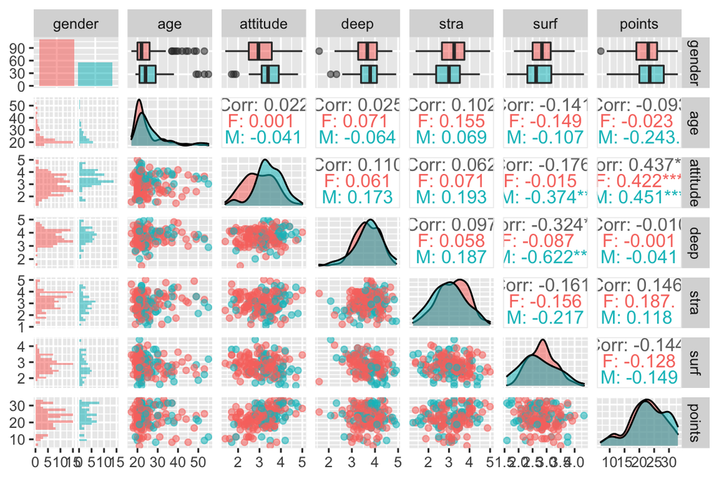

```r
library(ggplot2)
library(GGally)
ggpairs(learning2014, mapping = aes(col = gender, alpha = 0.3), lower = list(combo = wrap("facethist", bins = 20)))
```

### 3. Fitting a regression model

Based on the correlation between variables (analyzed above), I choose to fit a regression model in order to understand the impact of age, attitude and learning approach on exam points. As it turns out, the student’s attitude is highly significant (p < 0.001), while age and a strategic learning approach are moderately significant (p = 0.0981 and 0.0621 respectively).

```r
options(scipen = 999) #to indicate the minimal p-values with zeros
model1 <- lm(points ~ age + attitude + stra, data = learning2014)
summary(model1)
```

```
##
## Call:
## lm(formula = points ~ age + attitude + stra, data = learning2014)
##
## Residuals:
##      Min       1Q   Median       3Q      Max
## -18.1149  -3.2003   0.3303   3.4129  10.7599
##
## Coefficients:
##             Estimate Std. Error t value      Pr(>|t|)
## (Intercept) 10.89543    2.64834   4.114 0.00006171726 ***
## age         -0.08822    0.05302  -1.664        0.0981 .
## attitude     3.48077    0.56220   6.191 0.00000000472 ***
## stra         1.00371    0.53434   1.878        0.0621 .
## ---
## Signif. codes:  0 '***' 0.001 '**' 0.01 '*' 0.05 '.' 0.1 ' ' 1
##
## Residual standard error: 5.26 on 162 degrees of freedom
## Multiple R-squared:  0.2182, Adjusted R-squared:  0.2037
## F-statistic: 15.07 on 3 and 162 DF,  p-value: 0.0000000107
```

For the sake of comparison, I choose to make a second model. Excluding the modestly significant variables ‘age’ and ‘stra’ does not really seem to make any big difference (I have not conducted a hypothesis test between the models, but the intercept and attitude remain highly significant in both models.)

```r
model2 <- lm(points ~ attitude, data = learning2014)
summary(model2)
```

```
##
## Call:
## lm(formula = points ~ attitude, data = learning2014)
##
## Residuals:
##      Min       1Q   Median       3Q      Max
## -16.9763  -3.2119   0.4339   4.1534  10.6645
##
## Coefficients:
##             Estimate Std. Error t value      Pr(>|t|)
## (Intercept)  11.6372     1.8303   6.358 0.00000000195 ***
## attitude      3.5255     0.5674   6.214 0.00000000412 ***
## ---
## Signif. codes:  0 '***' 0.001 '**' 0.01 '*' 0.05 '.' 0.1 ' ' 1
##
## Residual standard error: 5.32 on 164 degrees of freedom
## Multiple R-squared:  0.1906, Adjusted R-squared:  0.1856
## F-statistic: 38.61 on 1 and 164 DF,  p-value: 0.000000004119
```

### 4. Predicting exam scores

I choose to go forth with the first model (model1). According to the model, exam scores can be predicted if we know the person’s age, attitude and scores measuring their strategic learning approach. As stated earlier, age is slightly negatively correlated with exam score, while attitude is to a much larger degree positively correlated with exam score. A strategic learning approach is moderately correlated with exam scores.

Let us make two example calculations, one for a moderately motivated young undergraduate (“Mike”), another for a highly motivated late bloomer (“Ritva”). Mike, age 22, scores on attitude and strategic learning 2 out of 5. Ritva, age 55, cores on attitude and strategic learning 5 out of 5. We can now predict their exam scores:

```r
students <- c('Mike','Ritva')
age <- c(22, 55)
attitude <- c(2,5)
stra <- c(2,5)
new_data <- data.frame(students, age, attitude, stra)
predict(model1, newdata = new_data)
```

```
##        1        2
## 17.92358 28.46580
```

Effectively, R here makes the following calculations using these coefficients:

```r
model1$coefficients
```

```
## (Intercept)         age    attitude        stra
## 10.89542805 -0.08821869  3.48076791  1.00371238
```

Calculating predictions using the coefficients can be done in the following manner. (Differences in decimals are due to rounding errors.)

```r
#Mike:
10.89543+(-0.08822*22)+(3.48077*2)+(1.00371*2)
```

```
## [1] 17.92355
```

```r
#Ritva:
10.89543+(-0.08822*55)+(3.48077*5)+(1.00371*5)
```

```
## [1] 28.46573
```

The R-squared value (0.2182) can be used to summarize how well the regression line fits the data. Using the R-squared value, we see that the model makes a fairly good fit, explaining about 22 per cent of the sample variance. (In a simplified manner, one could state that a fifth of the variation in exam scores is explained by the students’ attitudes.)

```r
summary(model1)$r.squared
```

```
## [1] 0.218172
```

### 5. Graphical model validation

In the following, I will produce three diagnostic plots in order to graphically explore the validity of my model assumptions. By analyzing residuals vs fitted values, I explore the validity of my model. Using the QQ-plot I explore whether errors are normally distributed. By exploring residuals vs leverage I want to find out whether there are any outliers. In this case, errors seem to be normally distributed, not correlated, and having a constant variance of Sigma^2. No severe outliers are identified.

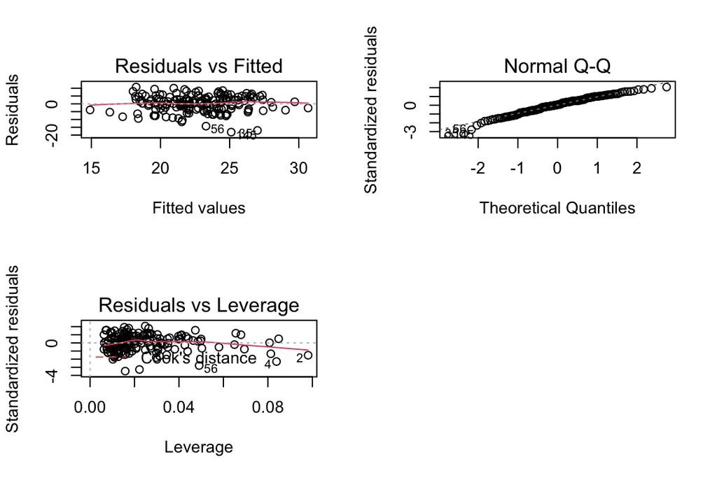

```r
par(mfrow = c(2,2))
plot(model1, which = c(1,2,5))
```

# RStudio Exercise 3

*Describe the work you have done this week and summarize your learning.*

- Describe your work and results clearly.
- Assume the reader has an introductory course level understanding of writing and reading R code as well as statistical methods.
- Assume the reader has no previous knowledge of your data or the more advanced methods you are using.

```r
date()
```

```
## [1] "Thu Nov 18 14:47:30 2021"
```

### 1. Exploring alcohol consumption among Portuguese secondary school students - an overview of the Alc dataset

The Alc dataset provides data on alcohol consumption among Portuguese secondary school students aged 15 to 22 (mean 16.6 years). The data was collected using school reports and questionnaires. Attributes include student grades, demographic, social and school related features. The Alc dataset was constructed by joining two separate sets on student performance in two distinct subjects: Mathematics and Portuguese. As some students were known to have appeared in both sets, duplicates were identified and removed.

```r
alc <- read.table("data/alc.csv", header = TRUE, sep = ",", stringsAsFactors = TRUE)
colnames(alc)
```

```
##  [1] "school"     "sex"        "age"        "address"    "famsize"
##  [6] "Pstatus"    "Medu"       "Fedu"       "Mjob"       "Fjob"
## [11] "reason"     "guardian"   "traveltime" "studytime"  "schoolsup"
## [16] "famsup"     "activities" "nursery"    "higher"     "internet"
## [21] "romantic"   "famrel"     "freetime"   "goout"      "Dalc"
## [26] "Walc"       "health"     "failures"   "paid"       "absences"
## [31] "G1"         "G2"         "G3"         "alc_use"    "high_use"
```

There are a number of variables that can be studied to understand student alcohol consumption. To get a quick overview of the content and distribution of each variable we can use the following code:

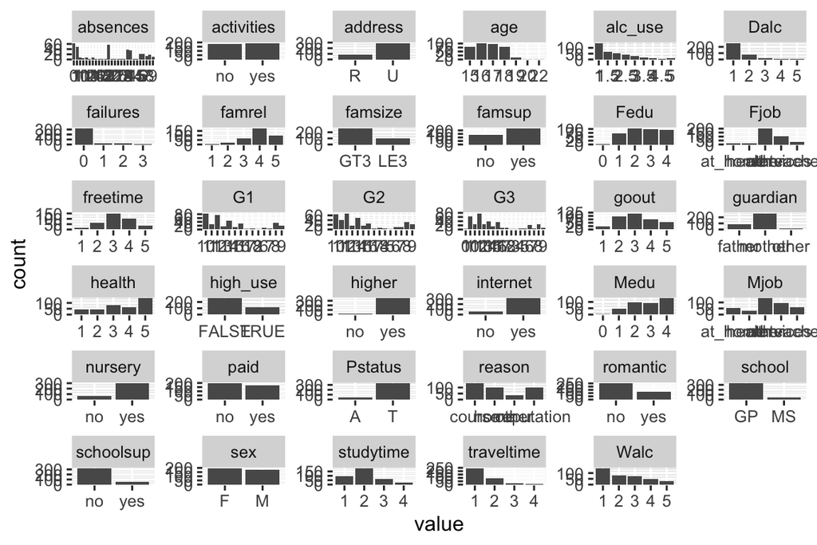

```r
fig.width=8
fig.height=6
library(tidyr); library(dplyr); library(ggplot2)
gather(alc) %>% ggplot(aes(value)) + facet_wrap("key", scales = "free") + geom_bar()
```

In order to find out which variables could possibly be statistically relevant, I begin by running a regression model explaining “alc_use” with all other variables (except for “Dalc”, “Walc” and “high_use” which are directly related to “alc_use”).

```r
# exclude variables "Dalc","Walc","high_use" which are directly related to "alc_use"
selvarnames <- names(alc) %in% c("Dalc","Walc","high_use")
alc2 <- alc[!selvarnames == T]
# create formula with where "alc_use" is explained by select variables (stored in alc2)
fmla <- as.formula(paste("alc_use~",paste(names(alc2)[1:31],collapse="+")))
# create linear regression model and read the summary
model1 <- lm(data=alc2, formula = fmla)
summary(model1)
```

```
##
## Call:
## lm(formula = fmla, data = alc2)
##
## Residuals:
##      Min       1Q   Median       3Q      Max
## -1.65003 -0.49853 -0.08492  0.38197  2.87986
##
## Coefficients:
##                   Estimate Std. Error t value        Pr(>|t|)
## (Intercept)      -0.308078   0.928209  -0.332        0.740172
## schoolMS         -0.206366   0.166819  -1.237        0.216943
## sexM              0.453517   0.098064   4.625 0.0000053993241 ***
## age               0.067109   0.043688   1.536        0.125478
## addressU         -0.232701   0.119806  -1.942        0.052951 .
## famsizeLE3        0.159470   0.099574   1.602        0.110221
## PstatusT          0.016944   0.148389   0.114        0.909161
## Medu              0.021611   0.065772   0.329        0.742688
## Fedu              0.055074   0.056854   0.969        0.333409
## Mjobhealth       -0.252106   0.227986  -1.106        0.269622
## Mjobother        -0.111991   0.146597  -0.764        0.445450
## Mjobservices     -0.135048   0.166597  -0.811        0.418166
## Mjobteacher      -0.066798   0.210155  -0.318        0.750799
## Fjobhealth        0.066192   0.305988   0.216        0.828870
## Fjobother         0.179164   0.224244   0.799        0.424887
## Fjobservices      0.399310   0.231379   1.726        0.085325 .
## Fjobteacher      -0.115857   0.271994  -0.426        0.670421
## reasonhome        0.045740   0.113435   0.403        0.687044
## reasonother       0.409977   0.164654   2.490        0.013270 *
## reasonreputation  0.056384   0.117446   0.480        0.631488
## guardianmother   -0.149224   0.108597  -1.374        0.170344
## guardianother    -0.232964   0.235168  -0.991        0.322593
## traveltime        0.152445   0.069143   2.205        0.028161 *
## studytime        -0.115010   0.058181  -1.977        0.048903 *
## schoolsupyes      0.021980   0.140610   0.156        0.875877
## famsupyes        -0.057759   0.097938  -0.590        0.555763
## activitiesyes    -0.185204   0.090385  -2.049        0.041249 *
## nurseryyes       -0.261139   0.112122  -2.329        0.020461 *
## higheryes         0.237373   0.241308   0.984        0.325989
## internetyes       0.042568   0.131414   0.324        0.746201
## romanticyes       0.052334   0.097849   0.535        0.593119
## famrel           -0.178569   0.048777  -3.661        0.000293 ***
## freetime          0.069539   0.048266   1.441        0.150606
## goout             0.293976   0.042174   6.971 0.0000000000173 ***
## health            0.056055   0.032523   1.724        0.085729 .
## failures          0.169898   0.089496   1.898        0.058521 .
## paidyes           0.287764   0.095692   3.007        0.002840 **
## absences          0.028011   0.008503   3.294        0.001094 **
## G1               -0.057193   0.037889  -1.509        0.132136
## G2                0.042812   0.047726   0.897        0.370356
## G3                0.006646   0.034650   0.192        0.848011
## ---
## Signif. codes:  0 '***' 0.001 '**' 0.01 '*' 0.05 '.' 0.1 ' ' 1
##
## Residual standard error: 0.8055 on 329 degrees of freedom
## Multiple R-squared:  0.4191, Adjusted R-squared:  0.3485
## F-statistic: 5.935 on 40 and 329 DF,  p-value: < 0.00000000000000022
```

From the regression model summary, I can read that male sex is a highly significant variable as well as the quality of family relationships and going out with friends. The variables “paid” (extra paid classes in Math or Portuguese) and “absences” (number of school absences) are fairly significant. Moderately significant variables include study time, travel time, whether the student attended nursery school and whether the student has taken part in extra-curricular activities.

In order to understand the relationship between high alcohol consumption and select variables, I choose to visualize the relationship between *high alcohol comsumption* and *sex/gender, family relationships, going out* and *study time*. For the analysis, I construct a subset comprising columns 2 (sex), 22 (family relationship), 24 (going out), 14 (study time) and 35 (high_use. The visualizsation is presented in sex-disaggregated form.

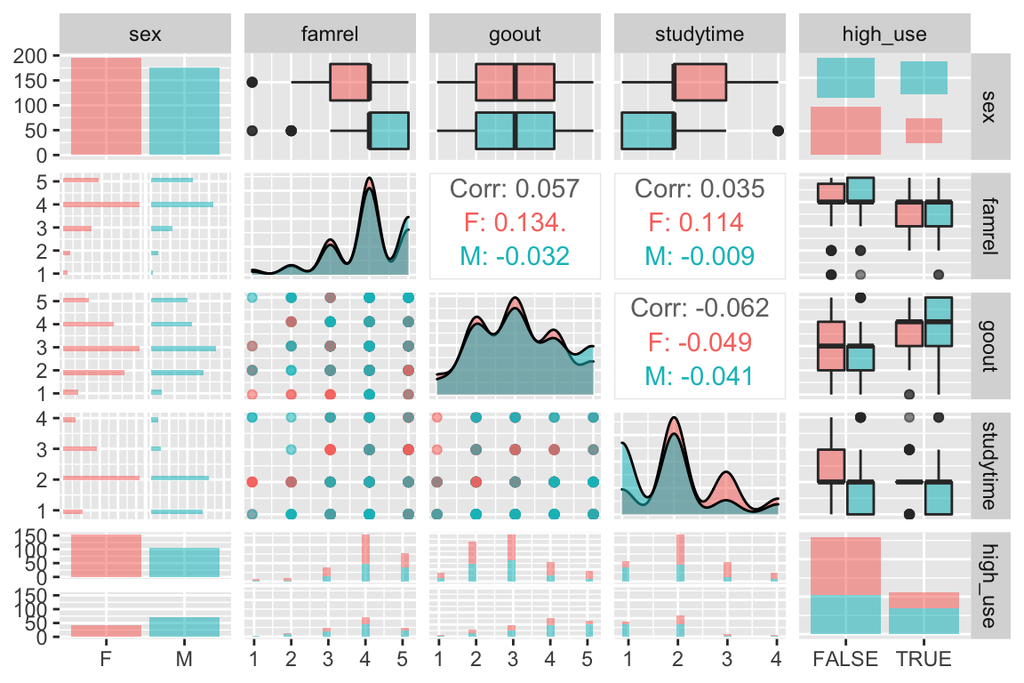

```r
library(ggplot2)
library(GGally)
#construct subset comprising columns 2 (sex), 22 (family relationship), 24 (going out), 14 (study time) and 35 (high_use)
alcpairs <- alc[, c(2, 22,24,14,35)]
#plot the pairs
ggpairs(alcpairs, mapping = aes(col=sex, alpha = 0.3), lower = list(combo = wrap("facethist", bins = 20)))
```

From the visual presentation, I can formulate the following working hypotheses for the select variables:

- *sex*: men are more likely than women to be high consumers
- *famrel*: students with high alcohol consumption generally score lower on the quality of family relationships
- *goout*: high alcohol consumption is strongly related to the frequency of going out, especially for men
- *study time*: students using much alcohol generally study fewer hours

The table below shows a summary of key statistics related to heavy and moderate drinkers (high_use = True/False) looking at four variables (three numeric and sex/gender).

```r
alc %>% group_by(sex, high_use) %>% summarise(count = n(), famrel=mean(famrel), goout=mean(goout), studytime=mean(studytime))
```

```
## # A tibble: 4 × 6
## # Groups:   sex [2]
##   sex   high_use count famrel goout studytime
##   <fct> <lgl>    <int>  <dbl> <dbl>     <dbl>
## 1 F     FALSE      154   3.92  2.95      2.34
## 2 F     TRUE        41   3.73  3.39      2
## 3 M     FALSE      105   4.13  2.70      1.90
## 4 M     TRUE        70   3.79  3.93      1.63
```

The table above indicates what has been stated previously: that Portuguese young heavy drinkers generally go out more than their moderately drinking peers. Also, they spend spend less time studying and they estimate their family relations to be worse.

To indicate the relationship between family relations and heavy drinking, let’s draw a separate box plot. As the chart indicates, moderate consumers of alcohol have better family ties The difference between groups is not, however, as big as the boxplot visualization would initially indicate. Therefore, red dots have been added to indicate mean values by group and sex.

The boxplot visualization indicates that students with high alcohol consumption score lower on the quality of family relationships, but the difference in mean values between groups is much lower than the visualization focused on integer values indicates: the difference is only 0.34 score points for males and 0.19 for females. In this respect, the boxplot visualization is easily misleading.

NB! 1) In both groups there are outliers scoring very low on family relations. In general, however, respondents have scored fairly high (median=4). NB! 2) The figure says little about whether the quality of family relations are the cause or consequence of high alcohol consumption.

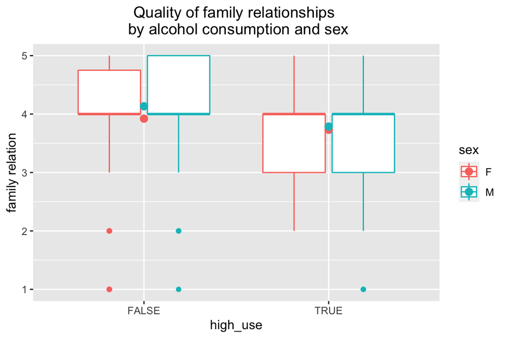

```r
# initialise a plot of high_use and famrel
g <- ggplot(alc, aes(x = high_use, y = famrel, col = sex))
g + geom_boxplot() + ylab("family relation") + ggtitle("Quality of family relationships \n by alcohol consumption and sex") + theme(plot.title = element_text(hjust = 0.5)) + stat_summary(fun=mean)
```

```r
alc %>% group_by(sex, high_use) %>% summarise(count = n(), famrel_mean=mean(famrel), famrel_median=median(famrel), goout_mean=mean(goout), goout_median=median(goout))
```

```
## # A tibble: 4 × 7
## # Groups:   sex [2]
##   sex   high_use count famrel_mean famrel_median goout_mean goout_median
##   <fct> <lgl>    <int>       <dbl>         <dbl>      <dbl>        <dbl>
## 1 F     FALSE      154        3.92             4       2.95            3
## 2 F     TRUE        41        3.73             4       3.39            4
## 3 M     FALSE      105        4.13             4       2.70            3
## 4 M     TRUE        70        3.79             4       3.93            4
```

### Applying logistic regression to understand the relationship between high alcohol usage and select variables

In the logistic regression model, the computational target variable is the log of odds. From this it follows that applying the exponent function to the fitted values gives us the odds. That is, the *exponents of the coefficients* can be interpreted as odds ratios between a unit change (vs no change) in the corresponding explanatory variable (according to the [course video](https://campus.datacamp.com/courses/helsinki-open-data-science/logistic-regression?ex=10) on Data Camp).

From this we see that with an odds ratio of over 2, males are more than twice as likely to have a “success” (that is, become heavy drinkers) compared to their female peers when controlling for family relations, going out and study time. The same goes for those student spending much time going out. On the other hand, those students with good family relations and spending much time studying are not as likely to become heavy drinkers; their odds ratios are only about 2/3 compared with their average peers.

The confidence intervals presented in the two rightmost columns (2.5 % and 97.5%) in the table below gives us an indication about the spread. From this we see for instance that there is a wider spread between males than between those going out. Although the odds ratio is about the same in both groups some males will have considerably higher odds compared to some outgoers.

The data presented here largely supports my initial working hypotheses about men being more likely than women to be high consumers, about students with high alcohol consumption generally scoring lower on the quality of family relationships, about high alcohol consumption being related to the frequency of going out and about lower study times being related to higher alcohol consumption.

However, revisiting the hypotheses reveals to me a somewhat erroneous wording and approach, focusing to much on the faults of those that I have called heavy drinkers (or those with a positive high_use variable). It would perhaps be more fair to comment on the relationship between high daily alcohol doses and background factors, and try to remove any judgmental attitudes.

Below is the printout of the summary of the logistic regression model and the table with odds ratios and confidence intervals.

```r
m <- glm(high_use ~ sex + famrel + goout + studytime, data = alc, family = "binomial")
summary(m)
```

```
##
## Call:
## glm(formula = high_use ~ sex + famrel + goout + studytime, family = "binomial",
##     data = alc)
##
## Deviance Residuals:
##     Min       1Q   Median       3Q      Max
## -1.5891  -0.7629  -0.4976   0.8304   2.6937
##
## Coefficients:
##             Estimate Std. Error z value       Pr(>|z|)
## (Intercept)  -1.2672     0.7312  -1.733        0.08309 .
## sexM          0.7959     0.2669   2.982        0.00286 **
## famrel       -0.4193     0.1399  -2.996        0.00273 **
## goout         0.7873     0.1230   6.399 0.000000000157 ***
## studytime    -0.4814     0.1711  -2.814        0.00490 **
## ---
## Signif. codes:  0 '***' 0.001 '**' 0.01 '*' 0.05 '.' 0.1 ' ' 1
##
## (Dispersion parameter for binomial family taken to be 1)
##
##     Null deviance: 452.04  on 369  degrees of freedom
## Residual deviance: 370.69  on 365  degrees of freedom
## AIC: 380.69
##
## Number of Fisher Scoring iterations: 4
```

```r
# compute odds ratios (OR)
OR <- coef(m) %>% exp
# compute confidence intervals (CI)
CI <- exp(confint(m))
# print out the odds ratios with their confidence intervals
cbind(OR, CI)
```

```
##                    OR      2.5 %    97.5 %
## (Intercept) 0.2816141 0.06545486 1.1622100
## sexM        2.2165443 1.31841735 3.7630180
## famrel      0.6575181 0.49791884 0.8636137
## goout       2.1974324 1.73873662 2.8198312
## studytime   0.6179355 0.43751933 0.8576353
```

Due to the chosen method at the start of this exercise, all of the variables controlled for were found to be statistically significant, one on a 0.1 per cent level and three on a 1 per cent level. I can therefore explore the predictive power of my model as such.

```r
# predict() the probability of high_use
probabilities <- predict(m, type = "response")
# add the predicted probabilities to "alc"
alc <- mutate(alc, probability = probabilities)
# use the probabilities to make a prediction of high_use
alc <- mutate(alc, prediction = probabilities > 0.5)
# tabulate the target variable versus the predictions. The numbers are the count of individuals.
table(high_use = alc$high_use, prediction = alc$prediction)
```

```
##         prediction
## high_use FALSE TRUE
##    FALSE   230   29
##    TRUE     59   52
```

```r
# tabulate the target variable versus the predictions. The table shows the proportions.
table(high_use = alc$high_use, prediction = alc$prediction) %>% prop.table() %>% addmargins()
```

```
##         prediction
## high_use      FALSE       TRUE        Sum
##    FALSE 0.62162162 0.07837838 0.70000000
##    TRUE  0.15945946 0.14054054 0.30000000
##    Sum   0.78108108 0.21891892 1.00000000
```

Based on the data and the reported alcohol intake, exactly 30 per cent of respondents (111 of 370) were classified as heavy drinkers (high_use = true). Equally, 70 per cent (259 individuals) were classified as non-heavy drinkers (high_use = false). According to the model, 29 of 259 moderately drinking individuals (11 per cent) were erroneously predicted to be heavy drinkers. Out of 111 heavy drinkers, a majority (59) were erroneously predicted not be high_users although they were according on the data.

Although the model did fairly well in recognizing non-heavy users, it did worse in predicting heavy drinkers among those who in fact were (based on the reported intake). Overall, the model predicted 78 per cent of respondents to be non-heavy users, while the actual proportion was 70 per cent.

The proportion of wrongly classified individuals is displayed visually in the plot below. As the visualization makes clear, the proportion of inaccurately classified individuals (i.e. the training error) is fairly high. The mean prediction error can be computed by defining a loss function and comparing classifications and probabilities. The calculation indicates that nearly 24 per cent are wrongly classified. I would not have expected the analysis to give such a high number. On the other hand, the model could become more accurate with a higher number of observations.

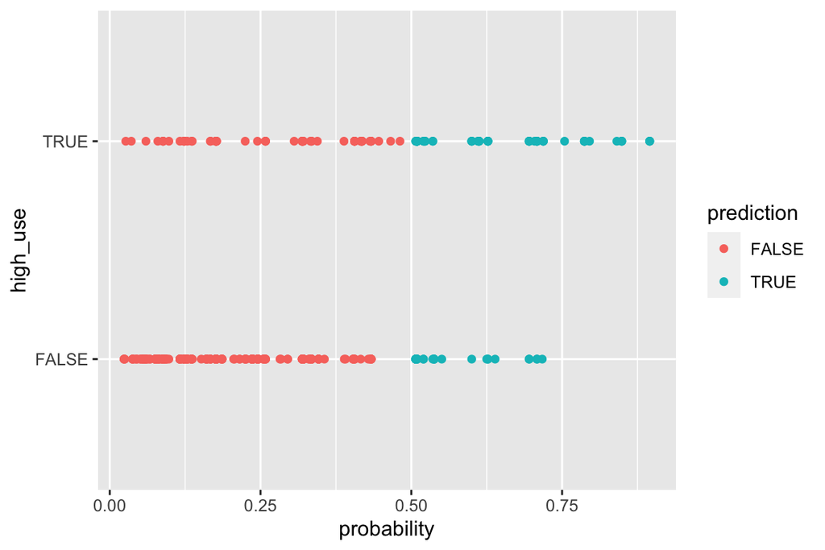

```r
# initialize a plot of 'high_use' versus 'probability' in 'alc'
g <- ggplot(alc, aes(x = probability, y = high_use, col = prediction))
# define the geom as points and draw the plot
g + geom_point()
```

```r
# define a loss function (mean prediction error)
loss_func <- function(class, prob) {
  n_wrong <- abs(class - prob) > 0.5
  mean(n_wrong)
}
# call loss_func to compute the average number of wrong predictions in the (training) data
loss_func(class = alc$high_use, prob = alc$probability)
```

```
## [1] 0.2378378
```

### A note on the usefulness of the model

At the loss rate of 24 per cent, it seems as if the model is not very accurate. Can I use the information? It depends on the purpose. For instance, if the goal was to target alcohol drinkers and feed them with advertisements on social media (assuming that heavy drinkers would be more inclined to buy booze), the information could definitely be useful (if one wanted to target alcohol ads at minors…). For identifying who will become an alcoholic in five years and who would need interrogative and intervening actions, the model is far too inaccurate. At this level of accuracy, one could perhaps only target information campaigns on the potential harms caused by drinking at an early age.

### Bonus: Performing ten-fold cross-validation on the model

```r
# Performing ten-fold cross-validation
library(boot)
cv <- cv.glm(data = alc, cost = loss_func, glmfit = m, K = 10)
# average number of wrong predictions in the cross validation
cv$delta[1]
```

```
## [1] 0.2432432
```

```r
# calculating the difference between using ten-fold cross-validation and a loss function
cv$delta[1]-loss_func(class = alc$high_use, prob = alc$probability)
```

```
## [1] 0.005405405
```

### Super-Bonus: Performing cross-validation to compare the performance of different logistic regression models

Finally, I will perform cross-validation to compare the performance of different logistic regression models using different sets of predictors. I start with the maximum number of predictors and explore the changes in the training and testing errors as I drop variables one by one. The original dataset contained 33 variables, but since *high_use* is directly related to *Walc* and *Dalc*, I choose to exclude these for computational feasibility.

In practice, I begin with creating a vector with running numbers in decreasing order from 31 to 1 indicating how many variables I will test at a time. I then create two more empty vectors, where I will save the results from the computational exercise. The three vectors will be used to construct the resulting data frame.

I then write a for loop to construct as many formulas as there are variables at any given time. I begin by making the cross-validation using the largest number of variables (31) The results are saved in a data frame along with the number of variables used. The resulting table will have three columns indicating *Number of variables, Prediction error rate* and *Training error rate* and 31 rows, one for every run.

Finally, I construct a plot indicating how both prediction and training errors decrease as the number of variables increase, with prediction errors always being greater. Looking at the resulting plot, I found it initially tough to digest the great variance and especially the initially increasing trend in prediction errors. But I guess that might have been be a result of a varying number of statistically significant variables being used in the different models.

The downside of the fairly long code written below is the time it takes to execute it. I have found that executing this last chunk alone - comparing different models with up to 31 variables - takes about three minutes. The time needed makes me relucant to run the code and test for any small changes, unless I have reduced the number of variables to a handful. If you have any suggestions on how to improve the code and speed up the process, I will gladly appreaciate your suggestions!

```r
library(dplyr)
library(boot)
howmanyvar <- 31 #Enter here how many variables you want to test for. 31 is the maximum. (33 variables were included in the original dataset but two of these will always be excluded for computational feasibility and avoidance of near-perfect correlation.)
#create vector, in sequence, starting from the number above, descending by 1.
v <- rev(seq(1,howmanyvar))
#create empty numeric vectors of same length for the results.
trainingerrors <- integer(howmanyvar)
predictionerrors <- integer(howmanyvar)
# define a loss function (average prediction error)
loss_func <- function(class, prob) {
  n_wrong <- abs(class - prob) > 0.5
  mean(n_wrong)
}
for(i in v) {
#Within the for loop, I first create temporary subsets called "alctest". I choose to exclude variables "Dalc", "Walc" as these were found to cause warnings when executing the logistic regression model and counting probabilities (highly correlated with "high_use"). I also exclude "probability" and "prediction" as the probability has been calculated based on the whole dataset and this will now be replaced.
exclvarnames <- names(alc) %in% c("Dalc","Walc", "alc_use", "probability", "prediction")
alctest <- alc[!exclvarnames == T]
#From the alctest subset I will gradually drop columns one at a time, starting from the number of variables entered in "howmanyvar". In alctest, 32 has become the index number for the variable high_use. Therefore, I always want to include that one.
alctest <- dplyr::select(alctest, 1:v[i], 32)
#However, I want to exclude "high_use" from the vector with columns names that I want to use on the right-hand side in the formula.
fnames <- names(alctest)[names(alctest) !="high_use"]
# create formula where "alc_use" is explained by the variables
f <- as.formula(paste("high_use~",paste(fnames,collapse="+")))
# run a logistic regression
m2 <- glm(f, data = alctest, family = "binomial")
# predict() the probability of high_use using model m2
probabilities <- predict(m2, type = "response")
# add the predicted probabilities to "alctest"
alctest <- mutate(alctest, probability = probabilities)
# compute the average number of wrong predictions in the (training) data and save the result in vector
trainingerrors[i] <- loss_func(alctest$high_use,alctest$probability)
# K-fold cross-validation
cv <- cv.glm(data = alctest, cost = loss_func, glmfit = m2, K = nrow(alctest))
# compute the average number of wrong predictions in the cross validation and save the result in vector
predictionerrors[i] <- cv$delta[1]
}
results <- data.frame(variables=v, trainingerrors=trainingerrors, predictionerrors=predictionerrors)
results
```

```
##    variables trainingerrors predictionerrors
## 1         31      0.1918919        0.2567568
## 2         30      0.1891892        0.2621622
## 3         29      0.1945946        0.2540541
## 4         28      0.1972973        0.2540541
## 5         27      0.2162162        0.2783784
## 6         26      0.2108108        0.2621622
## 7         25      0.2162162        0.2702703
## 8         24      0.2162162        0.2729730
## 9         23      0.2675676        0.3162162
## 10        22      0.2594595        0.3270270
## 11        21      0.2729730        0.3216216
## 12        20      0.2675676        0.3297297
## 13        19      0.2702703        0.3297297
## 14        18      0.2783784        0.3270270
```

[output cut: 17 more lines]

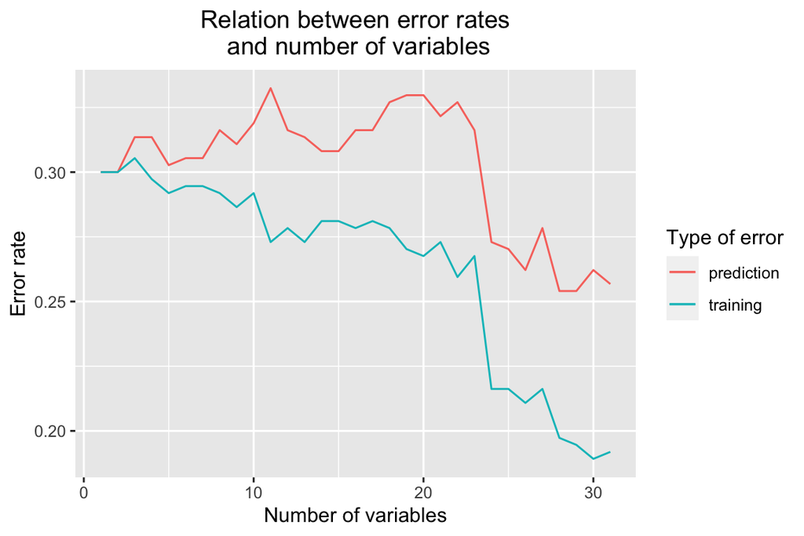

```r
p <- ggplot(results, aes(x=variables)) + geom_line(aes(y=predictionerrors, color="prediction")) + geom_line(aes(y=trainingerrors, color="training"))
p + ggtitle("Relation between error rates\n and number of variables") + theme(plot.title = element_text(hjust = 0.5)) + xlab("Number of variables") + ylab("Error rate") + scale_color_discrete(name="Type of error")
```